# Forecast 3 - Machine Learning-2026

# Assignment (ML)

Below is space for you to enter your forecasted values for Stony Brook flow in cubic feet per second, answer questions about your forecast, and write code to make your forecast better. The order is for easier grading of the material, but you will probably want to work on the latter sections before entering your forecasted values.

**Q1: Forecasting Work** *(25 points; values, code + comments, text, and figures as needed)*: What do you think will be the average daily flow of Stony Brook on the coming Friday, Saturday, and Sunday in [cfs]?

Please implement your forecast based upon the **Machine Learning course material**. Feel free to use the **assignments and precept work** as you prepare your forecast! Put your code and any needed markdown cells below that help you make this forecast.

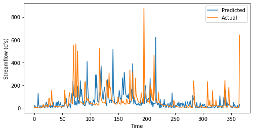

```
RMSE: 110.14770744737982
NSE: -0.2776099837523367
KGE: 0.18421025941325608
```

```python
# importing whatever is needed
import numpy as np
import pandas as pd
import matplotlib.pyplot as plt
import torch

from rmm_nn import RMM_NN
from transform import float32_clamp_scaling
from permetrics.regression import RegressionMetric

DEVICE = torch.device('cuda:0' if torch.cuda.is_available() else 'cpu')



# CNN FUNCTION FOR STREAMFLOW (just reusing and adjusting the given code)

def cnn_flow(n_batch, N, n_epoch, n_batch_test, learning_rate, train_data, test_data):

    nchannel = 2  # temp + precip

    model = RMM_NN(grid_size=[N], channels=nchannel)
    model.to(DEVICE)
    model.verbose = False
    model.use_dropout = True

    loss_fn = torch.nn.SmoothL1Loss()
    optimizer = torch.optim.Adam(model.parameters(), lr=learning_rate)

    # Normalization
    flow_max = np.max(train_data['flow'])
    precip_max = np.max(train_data['precip'])

    Temp_TRANSF = float32_clamp_scaling(
        src_range=[np.min(train_data['temp']), np.max(train_data['temp'])],
        dst_range=[-1, 1]
    )
    Flow_TRANSF = float32_clamp_scaling(src_range=[0, flow_max], dst_range=[0, 1])
    Precip_TRANSF = float32_clamp_scaling(src_range=[0, precip_max], dst_range=[0, 1])

    INV_FLOW_TRANSF = float32_clamp_scaling(src_range=[0, 1], dst_range=[0, flow_max])

    # Preparing training arrays
    input_temp = np.zeros((n_batch, nchannel, N))
    output_temp = np.zeros((n_batch, N))

    P_temp = Precip_TRANSF(np.asarray(train_data['precip']))
    T_temp = Temp_TRANSF(np.asarray(train_data['temp']))
    flow_temp = Flow_TRANSF(np.asarray(train_data['flow']))

    for ii in range(n_batch):
        i_from = ii * N
        i_to = i_from + N
        input_temp[ii, 0, :] = P_temp[i_from:i_to]
        input_temp[ii, 1, :] = T_temp[i_from:i_to]
        output_temp[ii, :] = flow_temp[i_from:i_to]

    torch_input = torch.from_numpy(input_temp).type(torch.FloatTensor).to(DEVICE)
    torch_label = torch.from_numpy(output_temp).type(torch.FloatTensor).to(DEVICE)

    # Training loop
    for epoch in range(n_epoch):
        optimizer.zero_grad()
        prediction = model(torch_input)
        loss = loss_fn(prediction, torch_label)
        loss.backward()
        optimizer.step()

    # Freezing model
    model.use_dropout = False
    for p in model.parameters():
        p.requires_grad = False

    # Preparing test input
    P_temp = Precip_TRANSF(np.asarray(test_data['precip']))
    T_temp = Temp_TRANSF(np.asarray(test_data['temp']))

    input_test = np.zeros((n_batch_test, nchannel, N))

    for ii in range(n_batch_test):
        i_from = ii * N
        i_to = i_from + N
        input_test[ii, 0, :] = P_temp[i_from:i_to]
        input_test[ii, 1, :] = T_temp[i_from:i_to]

    predict_input = torch.from_numpy(input_test).type(torch.FloatTensor).to(DEVICE)

    prediction = model(predict_input)
    model_output = INV_FLOW_TRANSF(prediction.data.cpu().numpy())

    model_plot = np.reshape(model_output, (N * n_batch_test))

    return model_plot



# LOADING DATA & CORRESPONDING DATES
# We have not altered any test data/ train data period as this is just extracting the code from HW4. We tried changing it in the forecast code.

train_start_date = '2014-10-01'
train_end_date   = '2019-09-30'
wtrain_end_date  = '2019-10-01'

test_start_date  = '2019-10-01'
test_end_date    = '2020-09-30'


#  Weather for Training

url = f"https://daymet.ornl.gov/single-pixel/send/saveData?lat=40.3573&lon=-74.6672&start={train_start_date}&end={wtrain_end_date}&format=csv"
weather = pd.read_csv(url, skiprows=6)

weather['temp'] = (weather['tmax (deg c)'] + weather['tmin (deg c)']) / 2
weather['precip'] = weather['prcp (mm/day)']

# Streamflow for Training

url = f"https://nwis.waterdata.usgs.gov/nj/nwis/uv/?cb_00060=on&format=rdb&site_no=01401000&begin_date={train_start_date}&end_date={train_end_date}"
flow = pd.read_csv(url, sep='\t', skiprows=25)

flow.columns = ['agency','site','datetime','tz','flow','id']
flow['datetime'] = pd.to_datetime(flow['datetime'])
flow_daily = flow.set_index('datetime')['flow'].resample('D').mean().reset_index()

train_data = pd.DataFrame({
    'temp': weather['temp'].values,
    'precip': weather['precip'].values,
    'flow': flow_daily['flow'].values
}).dropna().reset_index(drop=True)


# Weather for Testing

url = f"https://daymet.ornl.gov/single-pixel/send/saveData?lat=40.3573&lon=-74.6672&start={test_start_date}&end={test_end_date}&format=csv"
weather = pd.read_csv(url, skiprows=6)

weather['temp'] = (weather['tmax (deg c)'] + weather['tmin (deg c)']) / 2
weather['precip'] = weather['prcp (mm/day)']

# Streamflow for Testing
url = f"https://nwis.waterdata.usgs.gov/nj/nwis/uv/?cb_00060=on&format=rdb&site_no=01401000&begin_date={test_start_date}&end_date={test_end_date}"
flow = pd.read_csv(url, sep='\t', skiprows=25)

flow.columns = ['agency','site','datetime','tz','flow','id']
flow['datetime'] = pd.to_datetime(flow['datetime'])
flow_daily = flow.set_index('datetime')['flow'].resample('D').mean().reset_index()

test_data = pd.DataFrame({
    'temp': weather['temp'].values,
    'precip': weather['precip'].values,
    'flow': flow_daily['flow'].values
}).dropna().reset_index(drop=True)


# RUN THE MODEL
N = 366  # In HW4, we tried 3 and 366

n_batch = int(len(train_data) / N)
n_batch_test = int(len(test_data) / N)

n_epoch = 100
learning_rate = 1e-3

model_output = cnn_flow(
    n_batch, N, n_epoch,
    n_batch_test, learning_rate,
    train_data, test_data
)



# PLOT & RESULTS

plt.figure(figsize=(8,4))
plt.plot(model_output, label='Predicted')
plt.plot(test_data['flow'], label='Actual')
plt.xlabel('Time')
plt.ylabel('Streamflow (cfs)')
plt.legend()
plt.show()



# VALIDATION CHECKS
y_true = np.array(test_data['flow'])
y_pred = model_output

evaluator = RegressionMetric(y_true, y_pred)

print("RMSE:", evaluator.root_mean_squared_error())
print("NSE:", evaluator.nash_sutcliffe_efficiency())
print("KGE:", evaluator.kling_gupta_efficiency())
```